# UDACITY R Data Analysis Lesson 6

Trenton J. McKinney

Resources:

1. https://www.rdocumentation.org/packages/rmarkdown/versions/1.8/topics/html_notebook
2. http://rmarkdown.rstudio.com/html_document_format.html
3. https://bootswatch.com/

```r
library(readxl)
library(tibble)
library(ggplot2)
library(dplyr)
library(scales)
library(reshape2)
library(lubridate)
library(ggthemes)
library(gridExtra)
library(alr3)
library(rio)
```

### Lesson 6: Setup & General

```r
data("diamonds")
```

```r
?diamonds
```

```r
summary(diamonds)
```

```
     carat               cut        color        clarity          depth           table           price             x
 Min.   :0.2000   Fair     : 1610   D: 6775   SI1    :13065   Min.   :43.00   Min.   :43.00   Min.   :  326   Min.   : 0.000
 1st Qu.:0.4000   Good     : 4906   E: 9797   VS2    :12258   1st Qu.:61.00   1st Qu.:56.00   1st Qu.:  950   1st Qu.: 4.710
 Median :0.7000   Very Good:12082   F: 9542   SI2    : 9194   Median :61.80   Median :57.00   Median : 2401   Median : 5.700
 Mean   :0.7979   Premium  :13791   G:11292   VS1    : 8171   Mean   :61.75   Mean   :57.46   Mean   : 3933   Mean   : 5.731
 3rd Qu.:1.0400   Ideal    :21551   H: 8304   VVS2   : 5066   3rd Qu.:62.50   3rd Qu.:59.00   3rd Qu.: 5324   3rd Qu.: 6.540
 Max.   :5.0100                     I: 5422   VVS1   : 3655   Max.   :79.00   Max.   :95.00   Max.   :18823   Max.   :10.740
                                    J: 2808   (Other): 2531
       y                z
 Min.   : 0.000   Min.   : 0.000
 1st Qu.: 4.720   1st Qu.: 2.910
 Median : 5.710   Median : 3.530
 Mean   : 5.735   Mean   : 3.539
 3rd Qu.: 6.540   3rd Qu.: 4.040
 Max.   :58.900   Max.   :31.800
```

### Lesson 6.1 Quiz: Price vs x

Create a scatterplot of price vs x. using the ggplot syntax.

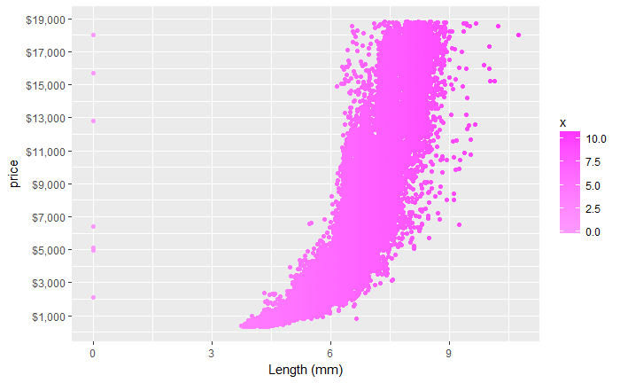

```r
ggplot(diamonds, aes(x = x, y = price, color = x)) +
  geom_point() +
  scale_y_continuous(breaks=seq(1000, 19000, 2000),label=dollar) +
  scale_color_gradient(low = "#FF99FF", high = "#FF33FF") +
  xlab("Length (mm)")
```

### Lesson 6.2 Quiz: Findings - price vs. x

There seems to be a few outliers and there’s a exponential increase in price per length

### Lesson 6.3 Quiz: Correlations

```r
with(diamonds, cor.test(price, x))
```

```
    Pearson's product-moment correlation

data:  price and x
t = 440.16, df = 53938, p-value < 2.2e-16
alternative hypothesis: true correlation is not equal to 0
95 percent confidence interval:
 0.8825835 0.8862594
sample estimates:
      cor
0.8844352
```

```r
with(diamonds, cor.test(price, y))
```

```
    Pearson's product-moment correlation

data:  price and y
t = 401.14, df = 53938, p-value < 2.2e-16
alternative hypothesis: true correlation is not equal to 0
95 percent confidence interval:
 0.8632867 0.8675241
sample estimates:
      cor
0.8654209
```

```r
with(diamonds, cor.test(price, z))
```

```
    Pearson's product-moment correlation

data:  price and z
t = 393.6, df = 53938, p-value < 2.2e-16
alternative hypothesis: true correlation is not equal to 0
95 percent confidence interval:
 0.8590541 0.8634131
sample estimates:
      cor
0.8612494
```

### Lesson 6.4 Quiz: price vs. depth

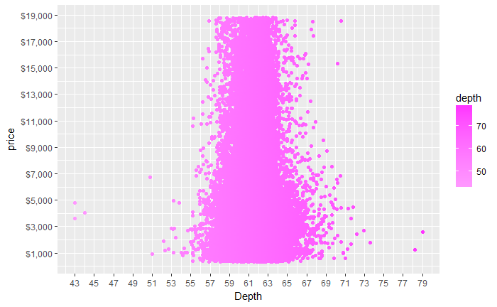

```r
p_pvd <- ggplot(diamonds, aes(x = depth, y = price, color = depth)) +
  scale_y_continuous(breaks=seq(1000, 19000, 2000),label=dollar) +
  scale_x_continuous(limits = c(43, 79), breaks = seq(43, 79, 2)) +
  scale_color_gradient(low = "#FF99FF", high = "#FF33FF") +
  xlab("Depth")
p_pvd +
  geom_point()
```

### Lesson 6.5 Quiz: Adjustments - price vs. depth

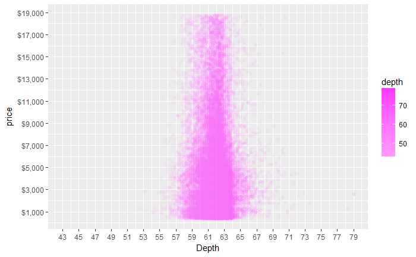

```r
p_pvd +
  geom_point(alpha = 1/20)
```

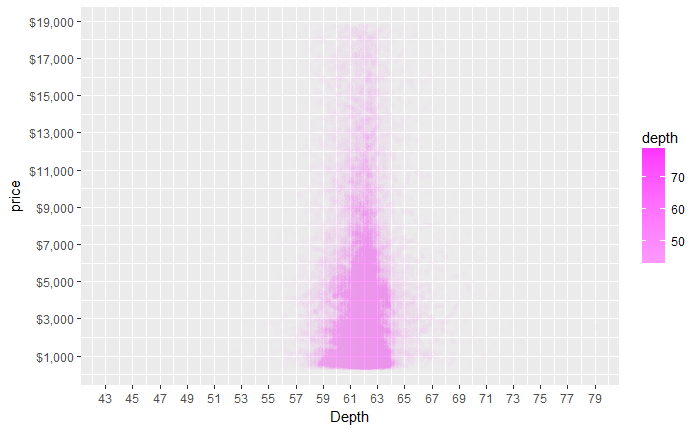

```r
p_pvd +
  geom_point(alpha = 1/100)
```

### Lesson 6.6 Quiz: Adjustments - Typical Depth Range

Most diamonds appear have a depth between 58 and 64

### Lesson 6.7 Quiz: Correlation - price and depth

```r
with(diamonds, cor.test(price, depth))
```

```
    Pearson's product-moment correlation

data:  price and depth
t = -2.473, df = 53938, p-value = 0.0134
alternative hypothesis: true correlation is not equal to 0
95 percent confidence interval:
 -0.019084756 -0.002208537
sample estimates:
       cor
-0.0106474
```

### Lesson 6.8 Quiz: price and carat

```r
summary(diamonds$carat)
```

```
   Min. 1st Qu.  Median    Mean 3rd Qu.    Max.
 0.2000  0.4000  0.7000  0.7979  1.0400  5.0100
```

```r
(quantile(diamonds$price, .99))
```

```
     99%
17378.22
```

```r
max(diamonds$price)
```

```
[1] 18823
```

```r
(quantile(diamonds$carat, .99))
```

```
 99%
2.18
```

```r
max(diamonds$carat)
```

```
[1] 5.01
```

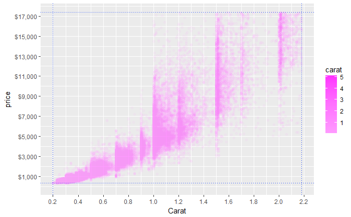

```r
ggplot(diamonds, aes(x = carat, y = price, color = carat)) +
  scale_y_continuous(limits = c(0, quantile(diamonds$price, .99)), breaks=seq(1000, 19000, 2000),label=dollar) +
  scale_x_continuous(limits = c(0.2, quantile(diamonds$carat, .99)), breaks = seq(0.2, 2.2, 0.2)) +
  scale_color_gradient(low = "#FF99FF", high = "#FF33FF") +
  xlab("Carat") +
  geom_point(alpha = 1/20) +
  geom_hline(yintercept=c(326, 17378.22), color='#0033FF', linetype=3) +
  geom_vline(xintercept=c(0.2, 2.18), color='#0033FF', linetype=3)
```

### Lesson 6.9 Quiz: price vs. volume

```r
diamonds$volume <- diamonds$x * diamonds$y * diamonds$z
```

```r
summary(diamonds$volume)
```

```
   Min. 1st Qu.  Median    Mean 3rd Qu.    Max.
   0.00   65.14  114.81  129.85  170.84 3840.60
```

```r
summary(diamonds$price)
```

```
   Min. 1st Qu.  Median    Mean 3rd Qu.    Max.
    326     950    2401    3933    5324   18823
```

Resources:

1. https://plot.ly/ggplot2/stat_smooth/
2. http://ggplot2.tidyverse.org/reference/geom_smooth.html

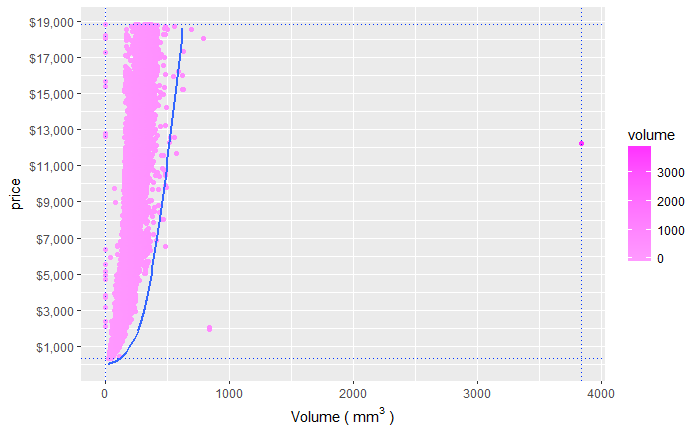

```r
ggplot(diamonds, aes(x = volume, y = price, color = volume)) +
  scale_y_continuous(breaks=seq(1000, 19000, 2000),label=dollar) +
  scale_color_gradient(low = "#FF99FF", high = "#FF33FF") +
  xlab(bquote('Volume ('~mm^3~')')) +
  geom_point() +
  geom_hline(yintercept=c(326, 18823), color='#0033FF', linetype=3) +
  geom_vline(xintercept=c(0, 3840.60), color='#0033FF', linetype=3) +
  geom_smooth(data = subset(diamonds, volume >=1 & volume < 630), aes(y = exp(x), x = volume))
```

### Lesson 6.10 Quiz: Findings - price vs. volume

There are outliers. Some volumes are 0. There’s an expensive diamond with a volume near 4000, and a cheaper diamond with a volume near 900.

You can find out how many diamonds have 0 volume by using count(diamonds$volume == 0). The count() function comes with the plyr package.

Note: If you ran the count function from plyr, you need to run this command in R to unload the plyr package. detach(“package:plyr”, unload=TRUE). The plyr package will conflict with the dplyr package in later exercises.

Depending on your investigation, it may or may not be important for you to understand how outliers, like these, came to be in your data.

```r
diamonds %>%
  count(volume == '0')
```

| volume == "0" | n |
| --- | --- |
| FALSE | 53920 |
| TRUE | 20 |

```r
subset(diamonds, (volume == "0"))
```

| carat | cut | color | clarity | depth | table | price | x | y | z | volume |
| --- | --- | --- | --- | --- | --- | --- | --- | --- | --- | --- |
| 1.00 | Premium | G | SI2 | 59.1 | 59 | 3142 | 6.55 | 6.48 | 0 | 0 |
| 1.01 | Premium | H | I1 | 58.1 | 59 | 3167 | 6.66 | 6.60 | 0 | 0 |
| 1.10 | Premium | G | SI2 | 63.0 | 59 | 3696 | 6.50 | 6.47 | 0 | 0 |
| 1.01 | Premium | F | SI2 | 59.2 | 58 | 3837 | 6.50 | 6.47 | 0 | 0 |
| 1.50 | Good | G | I1 | 64.0 | 61 | 4731 | 7.15 | 7.04 | 0 | 0 |
| 1.07 | Ideal | F | SI2 | 61.6 | 56 | 4954 | 0.00 | 6.62 | 0 | 0 |
| 1.00 | Very Good | H | VS2 | 63.3 | 53 | 5139 | 0.00 | 0.00 | 0 | 0 |
| 1.15 | Ideal | G | VS2 | 59.2 | 56 | 5564 | 6.88 | 6.83 | 0 | 0 |
| 1.14 | Fair | G | VS1 | 57.5 | 67 | 6381 | 0.00 | 0.00 | 0 | 0 |
| 2.18 | Premium | H | SI2 | 59.4 | 61 | 12631 | 8.49 | 8.45 | 0 | 0 |

[output cut: 10 more lines]

### Lesson 6.11 Quiz: Correlations on Subsets

```r
with(subset(diamonds, volume > 0 & volume < 800), cor.test(price, volume, method = 'pearson'))
```

```
    Pearson's product-moment correlation

data:  price and volume
t = 559.19, df = 53915, p-value < 2.2e-16
alternative hypothesis: true correlation is not equal to 0
95 percent confidence interval:
 0.9222944 0.9247772
sample estimates:
      cor
0.9235455
```

### Lesson 6.12 Quiz: Adjustments - price vs. volume

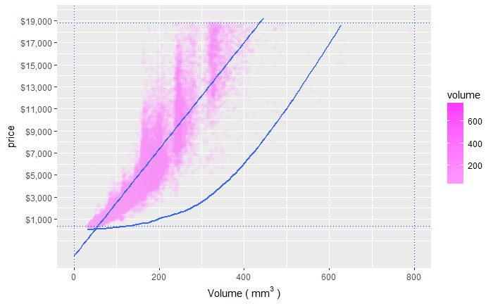

```r
ggplot(subset(diamonds, (volume > 0) & (volume < 800)), aes(x = volume, y = price, color = volume)) +
  geom_point(alpha = 1/20) +
  scale_y_continuous(breaks=seq(1000, 19000, 2000),label=dollar) +
  scale_color_gradient(low = "#FF99FF", high = "#FF33FF") +
  xlab(bquote('Volume ('~mm^3~')')) +
  geom_hline(yintercept=c(326, 18823), color='#0033FF', linetype=3) +
  geom_vline(xintercept=c(0, 800), color='#0033FF', linetype=3) +
  geom_smooth(data = subset(diamonds, volume >= 1 & volume < 630), aes(y = exp(x), x = volume)) +
  geom_smooth(data = subset(diamonds, volume < 450), method = 'lm', se = TRUE)
```

### Lesson 6.13 Quiz: Mean Price by Clarity

```r
diamondsByClarity<- diamonds %>%
  group_by(clarity) %>%
  summarise(mean_price = mean(price),
            median_price = median(price),
            min_price = min(price),
            max_price = max(price),
            n = n() ) %>%
  arrange(clarity)
```

### Lesson 6.14 Quiz: Bar Charts of Mean Price

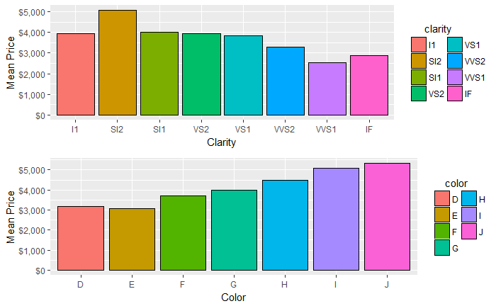

```r
diamonds_by_clarity <- group_by(diamonds, clarity)
diamonds_mp_by_clarity <- summarise(diamonds_by_clarity, mean_price = mean(price))
diamonds_by_color <- group_by(diamonds, color)
diamonds_mp_by_color <- summarise(diamonds_by_color, mean_price = mean(price))
p1 <- ggplot(diamonds_mp_by_clarity, aes(x=clarity, y=mean_price, fill=clarity)) +
  geom_bar(stat = "identity", color = "black") +
  guides(fill = guide_legend(ncol=2, title.hjust=0.3)) +
  xlab("Clarity") + ylab("Mean Price") +
  scale_y_continuous(breaks=seq(0, 5000, 1000),label=dollar)
p2 <- ggplot(diamonds_mp_by_color, aes(x=color, y=mean_price, fill=color)) +
  geom_bar(stat = "identity", color = "black") +
  guides(fill = guide_legend(ncol=2, title.hjust=0.4)) +
  xlab("Color") + ylab("Mean Price") +
  scale_y_continuous(breaks=seq(0, 5000, 1000),label=dollar)
grid.arrange(p1, p2)
```

### Lesson 6.15 Quiz: Trends in Mean Price

We think something odd is going here. These trends seem to go against our intuition.

Mean price tends to decrease as clarity improves. The same can be said for color.

We encourage you to look into the mean price across cut.

### Lesson 6.16a Quiz: Gapminder Revisited

The Gapminder website contains over 500 data sets with information about the world’s population. Your task is to continue the investigation you did at the end of Problem Set 3 or you can start fresh and choose a different data set from Gapminder.

If you’re feeling adventurous or want to try some data munging see if you can find a data set or scrape one from the web.

In your investigation, examine pairs of variable and create 2-5 plots that make use of the techniques from Lesson 4.

You can find a link to the Gapminder website in the Instructor Notes.

Once you’ve completed your investigation, create a post in the discussions that includes: 1. the variable(s) you investigated, your observations, and any summary statistics 2. snippets of code that created the plots 3. links to the images of your plots

Resources:

1. https://cran.r-project.org/web/packages/rio/vignettes/rio.html
2. https://github.com/pbiecek/PISA2012lite
3. http://fch808.github.io/Data-Analysis-with-R-Exercises.html
4. http://www.oecd.org/pisa/

This dataset includes 5 plausible values (PV) variables for each math, reading and science. Each PV was created from possibly imcomplete data. The PV for each subject is the mean of the data from each set.

```r
student2012 <- import("student2012.rda")
```

```r
head(student2012)
```

|  | CNT | SUBNATIO | STRATUM | OECD | NC | SCHOOLID | STIDSTD | ST01Q01 | ST02Q01 | ST03Q01 | ST03Q02 | ST04Q01 | ST05Q01 | ST06Q01 | ST07Q01 | ST07Q02 | ST07Q03 | ST08Q01 | ST09Q01 | ST115Q01 | ST11Q01 | ST11Q02 | ST11Q03 | ST11Q04 | ST11Q05 | ST11Q06 | ST13Q01 | ST14Q01 | ST14Q02 | … |
| --- | --- | --- | --- | --- | --- | --- | --- | --- | --- | --- | --- | --- | --- | --- | --- | --- | --- | --- | --- | --- | --- | --- | --- | --- | --- | --- | --- | --- | --- | --- |
| 1 | Albania | 0080000 | ALB0006 | Non-OECD | Albania | 0000001 | 00001 | 10 | 1 | 02 | 1996 | Female | No | 6 | No, never | No, never | No, never | None | None | 1 | Yes | Yes | Yes | Yes | NA | NA |  | No | No | … |
| 2 | Albania | 0080000 | ALB0006 | Non-OECD | Albania | 0000001 | 00002 | 10 | 1 | 02 | 1996 | Female | Yes, for more than one year | 7 | No, never | No, never | No, never | One or two times | None | 1 | Yes | Yes | NA | Yes | NA | NA |  | Yes | Yes | … |
| 3 | Albania | 0080000 | ALB0006 | Non-OECD | Albania | 0000001 | 00003 | 9 | 1 | 09 | 1996 | Female | Yes, for more than one year | 6 | No, never | No, never | No, never | None | None | 1 | Yes | Yes | No | Yes | No | No |  | Yes | Yes | … |
| 4 | Albania | 0080000 | ALB0006 | Non-OECD | Albania | 0000001 | 00004 | 9 | 1 | 08 | 1996 | Female | Yes, for more than one year | 6 | No, never | No, never | No, never | None | None | 1 | Yes | Yes | No | Yes | No | No |  | No | No | … |
| 5 | Albania | 0080000 | ALB0006 | Non-OECD | Albania | 0000001 | 00005 | 9 | 1 | 10 | 1996 | Female | Yes, for more than one year | 6 | No, never | No, never | No, never | One or two times | None | 2 | Yes | Yes | Yes | NA | NA | NA | She did not complete | No | No | … |
| 6 | Albania | 0080000 | ALB0006 | Non-OECD | Albania | 0000001 | 00006 | 9 | 1 | 09 | 1996 | Female | No | 6 | No, never | NA | NA | One or two times | None | 1 | Yes | Yes | No | Yes | Yes | No |  | No | No | … |

```r
student_data <- student2012 %>%
  mutate(Math = as.numeric((PV1MATH + PV2MATH + PV3MATH + PV4MATH + PV5MATH)/5),
         Reading = as.numeric((PV1READ + PV2READ + PV3READ + PV4READ + PV5READ)/5),
         Science = as.numeric((PV1SCIE + PV1SCIE + PV1SCIE + PV1SCIE + PV1SCIE)/5)) %>%
  select(Gender = ST04Q01,
         birth_year = ST03Q02,
         birth_month = ST03Q01,
         PC_at_home = ST26Q04,
         Country = CNT,
         Math, Reading, Science)
```

```r
student_scores <- student_data %>%
  group_by(Country, Gender) %>%
  summarise(math_mean = mean(Math),
            reading_mean = mean(Reading),
            science_mean = mean(Science),
            n = n()) %>%
  arrange(math_mean, reading_mean, science_mean)
```

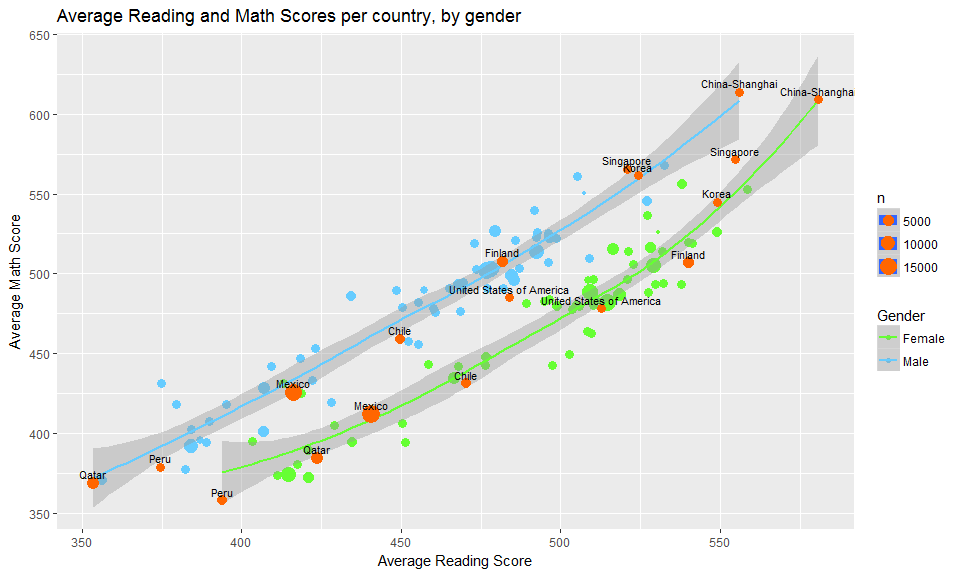

```r
ggplot(student_scores, aes(x = reading_mean, y = math_mean, color = Gender, size=n)) +
  geom_point() +
  scale_color_manual(values = c("Female" = "#66FF33", "Male" = "#66CCFF")) +
  geom_smooth(method = 'loess') +
  geom_point(data = subset(student_scores,
                           Country %in% c("United States of America", "Mexico", "Peru", "Qatar",
                                          "China-Shanghai", "Singapore", "Korea", "Finland", "Chile")),
             color="#FF6600") +
  geom_text(data = subset(student_scores,
                          Country %in% c("United States of America", "Mexico", "Peru", "Qatar",
                                         "China-Shanghai", "Singapore", "Korea", "Finland", "Chile")),
            aes(label = Country),
            color = "black",
            size = 3,
            vjust = -0.5) +
  ylab("Average Math Score") +
  xlab("Average Reading Score") +
  ggtitle("Average Reading and Math Scores per country, by gender")
```

```r
with(subset(student_scores, Gender=="Female"), cor.test(math_mean, reading_mean, method = 'pearson'))
```

```
    Pearson's product-moment correlation

data:  math_mean and reading_mean
t = 23.188, df = 63, p-value < 2.2e-16
alternative hypothesis: true correlation is not equal to 0
95 percent confidence interval:
 0.9128554 0.9668924
sample estimates:
      cor
0.9461085
```

```r
with(subset(student_scores, Gender=="Male"), cor.test(math_mean, reading_mean, method = 'pearson'))
```

```
    Pearson's product-moment correlation

data:  math_mean and reading_mean
t = 28.421, df = 63, p-value < 2.2e-16
alternative hypothesis: true correlation is not equal to 0
95 percent confidence interval:
 0.9400794 0.9774343
sample estimates:
      cor
0.9631444
```

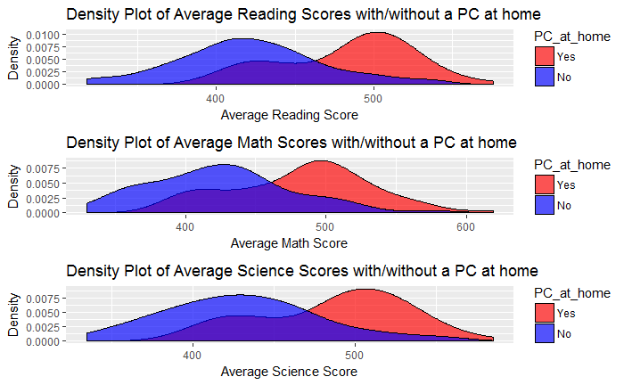

```r
student_PC <- student_data %>%
  group_by(Country, PC_at_home) %>%
  summarise(mean_math = mean(Math),
            mean_reading = mean(Reading),
            mean_science = mean(Science),
            count = n() ) %>%
  arrange(mean_math, mean_reading, mean_science)
g1 <- ggplot(subset(student_PC, !(is.na(PC_at_home))), aes(x = mean_reading, fill = PC_at_home, size=count)) +
  geom_density(alpha=0.66) +
  scale_fill_manual(values = c("red","blue")) +
  ylab("Density") +
  xlab("Average Reading Score") +
  ggtitle("Density Plot of Average Reading Scores with/without a PC at home")
g2 <- ggplot(subset(student_PC, !(is.na(PC_at_home))), aes(x = mean_math, fill = PC_at_home, size=count)) +
  geom_density(alpha=0.66) +
  scale_fill_manual(values = c("red","blue")) +
  ylab("Density") +
  xlab("Average Math Score") +
  ggtitle("Density Plot of Average Math Scores with/without a PC at home")
g3 <- ggplot(subset(student_PC, !(is.na(PC_at_home))), aes(x = mean_science, fill = PC_at_home, size=count)) +
  geom_density(alpha=0.66) +
  scale_fill_manual(values = c("red","blue")) +
  ylab("Density") +
  xlab("Average Science Score") +
  ggtitle("Density Plot of Average Science Scores with/without a PC at home")
grid.arrange(g1, g2, g3, ncol=1)
```

### Lesson 6.16b Quiz: US Educational Finances

https://www.kaggle.com/noriuk/us-educational-finances

```r
exp_summary <- import("./us-educational-finances/elsect_summary.csv")
head(exp_summary, 10)
```

|  | STATE | YEAR | ENROLL | TOTAL_REVENUE | FEDERAL_REVENUE | STATE_REVENUE | LOCAL_REVENUE | TOTAL_EXPENDITURE | PROGRAM_CURRENT_EXPENDITURE | INSTRUCTION_EXPENDITURE | SUPPORT_SERVICES_EXPENDITURE | PROGRAM_OTHER_EXPENDITURE | PROGRAM_NON_ELSEC_EXPENDITURE | CAPITAL_OUTLAY_EXPENDITURE |
| --- | --- | --- | --- | --- | --- | --- | --- | --- | --- | --- | --- | --- | --- | --- |
| 1 | Alabama | 1992 | NA | 2678885 | 304177 | 1659028 | 715680 | 2653798 | 2425255 | 1481703 | 735036 | 208516 | 22560 | 174053 |
| 2 | Alaska | 1992 | NA | 1049591 | 106780 | 720711 | 222100 | 972488 | 884141 | 498362 | 350902 | 34877 | 5906 | 37451 |
| 3 | Arizona | 1992 | NA | 3258079 | 297888 | 1369815 | 1590376 | 3401580 | 2577217 | 1435908 | 1007732 | 133577 | 14805 | 609114 |
| 4 | Arkansas | 1992 | NA | 1711959 | 178571 | 958785 | 574603 | 1743022 | 1543213 | 964323 | 483488 | 95402 | 2587 | 145212 |
| 5 | California | 1992 | NA | 26260025 | 2072470 | 16546514 | 7641041 | 27138832 | 24116146 | 14358922 | 8520926 | 1236298 | 541582 | 2044688 |
| 6 | Colorado | 1992 | NA | 3185173 | 163253 | 1307986 | 1713934 | 3264826 | 2770124 | 1642466 | 1035970 | 91688 | 7362 | 364760 |
| 7 | Connecticut | 1992 | NA | 3834302 | 143542 | 1342539 | 2348221 | 3721338 | 3409155 | 2148041 | 1142600 | 118514 | 15599 | 48542 |
| 8 | Delaware | 1992 | NA | 645233 | 45945 | 420942 | 178346 | 638784 | 588836 | 372722 | 194915 | 21199 | 4586 | 30595 |
| 9 | District of Columbia | 1992 | NA | 709480 | 64749 | 0 | 644731 | 742893 | 675319 | 329160 | 316679 | 29480 | 6040 | 47272 |
| 10 | Florida | 1992 | NA | 11506299 | 788420 | 5683949 | 5033930 | 11305642 | 9045166 | 5166374 | 3410440 | 468352 | 337685 | 1667826 |

```r
summary(exp_summary)
```

```
    STATE                YEAR          ENROLL        TOTAL_REVENUE      FEDERAL_REVENUE   STATE_REVENUE      LOCAL_REVENUE
 Length:1224        Min.   :1992   Min.   :  43866   Min.   :  465650   Min.   :  31020   Min.   :       0   Min.   :   22093
 Class :character   1st Qu.:1998   1st Qu.: 262935   1st Qu.: 2178702   1st Qu.: 187220   1st Qu.: 1134351   1st Qu.:  710264
 Mode  :character   Median :2004   Median : 648084   Median : 5031386   Median : 397988   Median : 2491838   Median : 2027902
                    Mean   :2004   Mean   : 916026   Mean   : 8924060   Mean   : 755538   Mean   : 4139964   Mean   : 4028558
                    3rd Qu.:2009   3rd Qu.:1009200   3rd Qu.:10620363   3rd Qu.: 816538   3rd Qu.: 4833075   3rd Qu.: 4683521
                    Max.   :2015   Max.   :6307022   Max.   :78248042   Max.   :9990221   Max.   :43187637   Max.   :34941513
                                   NA's   :51
 TOTAL_EXPENDITURE  PROGRAM_CURRENT_EXPENDITURE INSTRUCTION_EXPENDITURE SUPPORT_SERVICES_EXPENDITURE PROGRAM_OTHER_EXPENDITURE
 Min.   :  481665   Min.   :  427820            Min.   :  265549        Min.   :  139963             Min.   :   9256
 1st Qu.: 2154830   1st Qu.: 1119316            1st Qu.: 1146924        1st Qu.:  625809             1st Qu.:  51260
 Median : 5134935   Median : 2883322            Median : 2606185        Median : 1513362             Median : 133577
 Mean   : 9037118   Mean   : 4635230            Mean   : 4674538        Mean   : 2631397             Mean   : 195969
 3rd Qu.:10575426   3rd Qu.: 5422042            3rd Qu.: 5521131        3rd Qu.: 3129162             3rd Qu.: 214599
 Max.   :78365958   Max.   :29993814            Max.   :41954260        Max.   :23501848             Max.   :1236298
                    NA's   :918                                                                      NA's   :1173
 PROGRAM_NON_ELSEC_EXPENDITURE CAPITAL_OUTLAY_EXPENDITURE
 Min.   :   334                Min.   :   12708
 1st Qu.:  4686                1st Qu.:  178340
 Median : 17048                Median :  497220
 Mean   : 61471                Mean   :  894406
 3rd Qu.: 59574                3rd Qu.:  963384
 Max.   :541582                Max.   :10223657
 NA's   :1173
```

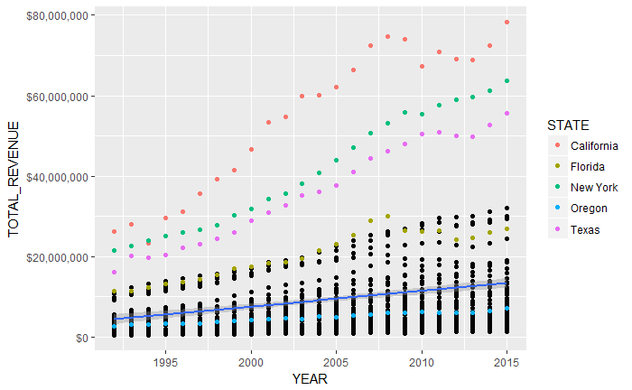

```r
ggplot(exp_summary, aes(x = YEAR, y = TOTAL_REVENUE)) +
  geom_point() +
  geom_smooth(method = 'gam') +
  geom_point(data = subset(exp_summary, STATE %in% c("California", "New York", "Texas", "Oregon", "Florida")), aes(color = STATE)) +
  scale_y_continuous(labels = dollar)
```

```r
with(exp_summary, cor.test(YEAR, TOTAL_REVENUE, method = 'pearson'))
```

```
    Pearson's product-moment correlation

data:  YEAR and TOTAL_REVENUE
t = 8.4979, df = 1222, p-value < 2.2e-16
alternative hypothesis: true correlation is not equal to 0
95 percent confidence interval:
 0.1826000 0.2884294
sample estimates:
      cor
0.2362151
```

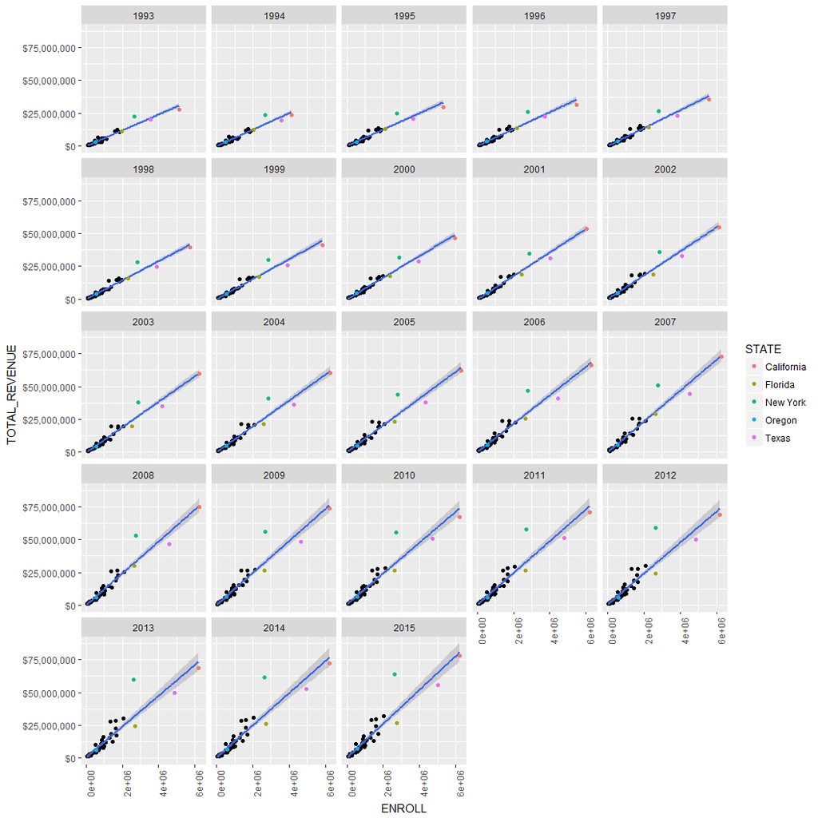

```r
ggplot(subset(exp_summary, YEAR > 1992) , aes(x = ENROLL, y = TOTAL_REVENUE)) +
  geom_point() +
  geom_smooth(method = 'gam') +
  geom_point(data = subset(exp_summary, YEAR > 1992 & STATE %in% c("California", "New York", "Texas", "Oregon", "Florida")), aes(color = STATE)) +
  scale_y_continuous(labels = dollar) +
  facet_wrap(~YEAR) +
  theme(axis.text.x = element_text(angle = 90))
```

```r
with(subset(exp_summary, YEAR > 1992), cor.test(ENROLL, TOTAL_REVENUE, method = 'pearson'))
```

```
    Pearson's product-moment correlation

data:  ENROLL and TOTAL_REVENUE
t = 78.635, df = 1171, p-value < 2.2e-16
alternative hypothesis: true correlation is not equal to 0
95 percent confidence interval:
 0.9073202 0.9255977
sample estimates:
      cor
0.9169386
```

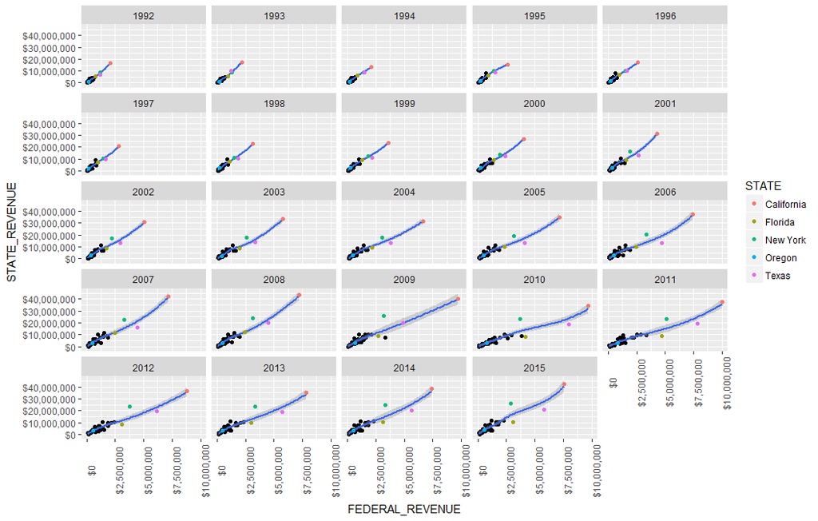

```r
ggplot(exp_summary, aes(x = FEDERAL_REVENUE, y = STATE_REVENUE)) +
  geom_point() +
  geom_smooth(method = 'loess') +
  geom_point(data = subset(exp_summary, STATE %in% c("California", "New York", "Texas", "Oregon", "Florida")), aes(color = STATE)) +
  facet_wrap(~YEAR) +
  scale_x_continuous(labels = dollar) + scale_y_continuous(labels = dollar) +
  theme(axis.text.x = element_text(angle = 90))
```

```r
with(exp_summary, cor.test(FEDERAL_REVENUE, STATE_REVENUE, method = 'pearson'))
```

```
    Pearson's product-moment correlation

data:  FEDERAL_REVENUE and STATE_REVENUE
t = 82.62, df = 1222, p-value < 2.2e-16
alternative hypothesis: true correlation is not equal to 0
95 percent confidence interval:
 0.9119868 0.9290477
sample estimates:
      cor
0.9209574
```

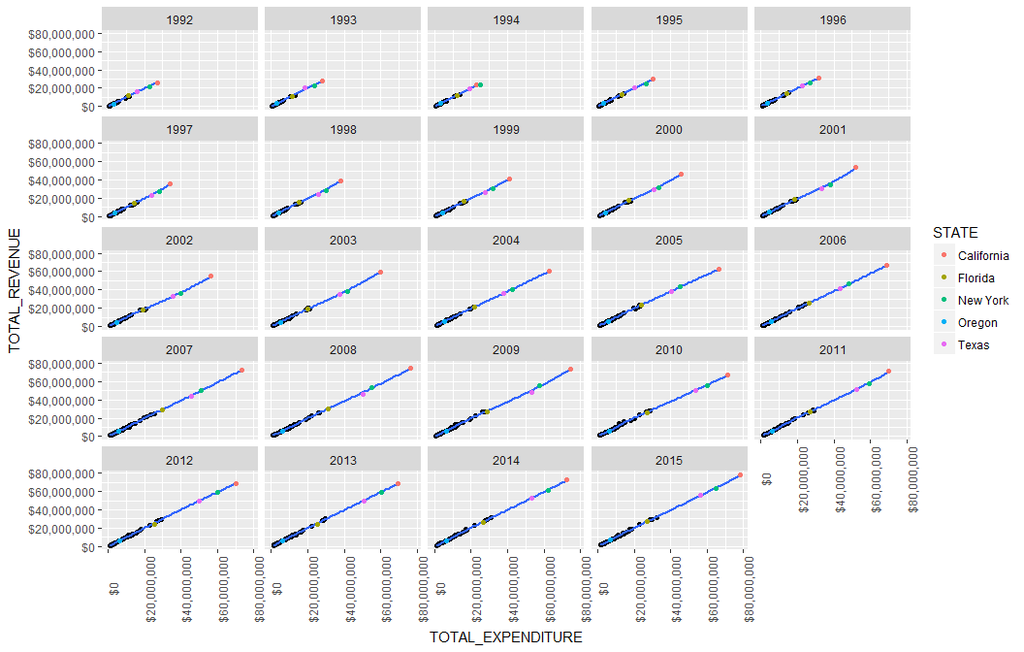

```r
ggplot(exp_summary, aes(x = TOTAL_EXPENDITURE, y = TOTAL_REVENUE)) +
  geom_point() +
  geom_smooth(method = 'loess') +
  geom_point(data = subset(exp_summary, STATE %in% c("California", "New York", "Texas", "Oregon", "Florida")), aes(color = STATE)) +
  scale_x_continuous(labels = dollar) + scale_y_continuous(labels = dollar) +
  facet_wrap(~YEAR) +
  theme(axis.text.x = element_text(angle = 90))
```

```r
with(exp_summary, cor.test(TOTAL_EXPENDITURE, TOTAL_REVENUE, method = 'pearson'))
```

```
    Pearson's product-moment correlation

data:  TOTAL_EXPENDITURE and TOTAL_REVENUE
t = 807.05, df = 1222, p-value < 2.2e-16
alternative hypothesis: true correlation is not equal to 0
95 percent confidence interval:
 0.9989521 0.9991626
sample estimates:
      cor
0.9990632
```